# Regression models, model fit and prediction errors

Ahsan Ahmad

March 24, 2024

# 1 Libraries

```r
library(tidyverse)
library(psych)
library(caret)
library(rminer)
library(rmarkdown)
library(matrixStats)
library(knitr)
library(rpart)
library(RWeka)
```

# 2 Set up, data import, data exploration, data partitioning, and inspection code

Before proceeding with the analysis, it’s essential to set up the working directory and import the data from a CSV file named ‘NA_sales_filtered.csv’. This code chunk also inspects the structure of the dataset and converts string data into factors for further analysis. Latly, the code chunk does data partition to create a 70-30 split for train and test data sets.

```r
# Setting up working directory and importing data from a csv file

cloud_wd <- getwd()
setwd(cloud_wd)

NA_sales <- read.csv(file = "NA_sales_filtered.csv", stringsAsFactors = TRUE)

# Looking at the structure and summary of the data

str(NA_sales)
```

```
## 'data.frame':    6345 obs. of  9 variables:
##  $ Name        : Factor w/ 4088 levels "E\xe5\xe1O\xe5\xe1E: Eve of Extinction",..: 1203 1205 3578 1204 3402 1964 3814 3813 3968 941 ...
##  $ Platform    : Factor w/ 16 levels "3DS","DS","GBA",..: 6 7 5 6 6 7 8 8 5 6 ...
##  $ Genre       : Factor w/ 12 levels "Action","Adventure",..: 8 8 10 8 3 9 1 1 8 1 ...
##  $ Rating      : Factor w/ 5 levels "E","E10+","M",..: 5 5 5 5 5 5 5 5 5 5 ...
##  $ Critic_Score: int  92 92 86 90 96 88 92 96 93 87 ...
##  $ Critic_Count: int  20 53 75 24 15 29 97 105 57 22 ...
##  $ User_Score  : int  91 86 75 85 90 84 82 87 72 80 ...
##  $ User_Count  : int  1282 1056 886 644 367 135 3712 5187 2182 78 ...
##  $ NA_Sales    : num  3.01 2.91 0.99 2.28 3.27 2.93 2.77 3.27 0.08 3.11 ...
```

```r
summary(NA_sales)
```

```
##                                           Name         Platform
##  Madden NFL 07                              :   8   PS2    :1135
##  LEGO Batman: The Videogame                 :   7   X360   : 848
##  LEGO Indiana Jones: The Original Adventures:   7   PS3    : 749
##  LEGO Star Wars II: The Original Trilogy    :   7   XB     : 578
##  Madden NFL 08                              :   7   Wii    : 475
##  Need for Speed: Most Wanted                :   7   DS     : 457
##  (Other)                                    :6302   (Other):2103
##           Genre          Rating      Critic_Score    Critic_Count
##  Action      :1549   E      :1968   Min.   :13.00   Min.   :  3.00
##  Sports      : 921   E10+   : 877   1st Qu.:61.00   1st Qu.: 14.00
##  Shooter     : 798   M      :1295   Median :72.00   Median : 25.00
##  Role-Playing: 643   missing:  23   Mean   :69.82   Mean   : 28.97
##  Racing      : 537   T      :2182   3rd Qu.:80.00   3rd Qu.: 40.00
##  Platform    : 386                  Max.   :98.00   Max.   :113.00
##  (Other)     :1511
##    User_Score      User_Count         NA_Sales
##  Min.   : 5.00   Min.   :    4.0   Min.   :0.0100
##  1st Qu.:64.00   1st Qu.:   10.0   1st Qu.:0.0800
##  Median :74.00   Median :   24.0   Median :0.1700
##  Mean   :70.77   Mean   :  152.7   Mean   :0.3542
##  3rd Qu.:81.00   3rd Qu.:   77.0   3rd Qu.:0.4100
##  Max.   :95.00   Max.   :10665.0   Max.   :3.4900
##
```

```r
# Using cor and pairs.panels to compute correlation matrix and display correlations of the listed numeric variables

NA_sales %>% select(Critic_Score, Critic_Count, User_Score, User_Count, NA_Sales) %>% cor()
```

```
##              Critic_Score Critic_Count User_Score User_Count  NA_Sales
## Critic_Score    1.0000000    0.3903993 0.58454759 0.24368767 0.3529736
## Critic_Count    0.3903993    1.0000000 0.19276210 0.34805984 0.3435046
## User_Score      0.5845476    0.1927621 1.00000000 0.01239754 0.1453508
## User_Count      0.2436877    0.3480598 0.01239754 1.00000000 0.2683929
## NA_Sales        0.3529736    0.3435046 0.14535079 0.26839294 1.0000000
```

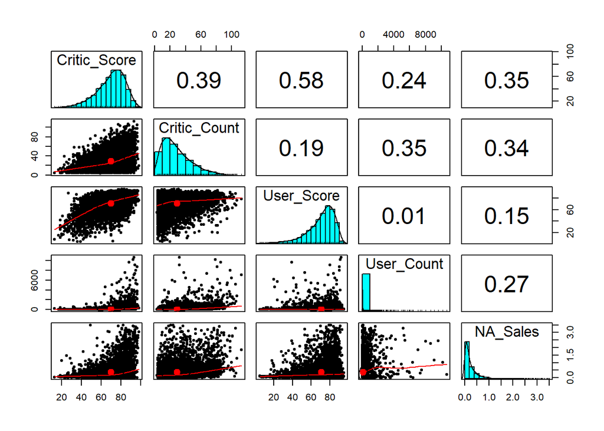

```r
NA_sales %>% select(Critic_Score, Critic_Count, User_Score, User_Count, NA_Sales) %>% pairs.panels()
```

```r
# Removing names column from the dataset and storing it in a new dataset

Sales <- NA_sales[,-1]

# Creating a linear regression model with the new dataset

linear_reg_model <- lm(NA_Sales ~ ., data = Sales)
summary(linear_reg_model)
```

```
##
## Call:
## lm(formula = NA_Sales ~ ., data = Sales)
##
## Residuals:
##     Min      1Q  Median      3Q     Max
## -1.9381 -0.2315 -0.0818  0.0978  3.1769
##
## Coefficients:
##                     Estimate Std. Error t value Pr(>|t|)
## (Intercept)       -4.045e-01  4.796e-02  -8.435  < 2e-16 ***
## PlatformDS         1.547e-01  4.088e-02   3.783 0.000156 ***
## PlatformGBA        1.705e-01  4.573e-02   3.729 0.000194 ***
## PlatformGC         8.918e-02  4.276e-02   2.085 0.037071 *
## PlatformPC        -3.054e-01  4.554e-02  -6.706 2.17e-11 ***
## PlatformPS         4.075e-01  5.080e-02   8.020 1.25e-15 ***
## PlatformPS2        1.954e-01  3.851e-02   5.074 4.00e-07 ***
## PlatformPS3        9.718e-02  3.929e-02   2.473 0.013422 *
## PlatformPS4       -7.379e-02  4.670e-02  -1.580 0.114165
## PlatformPSP        4.007e-02  4.201e-02   0.954 0.340130
## PlatformPSV       -1.176e-01  5.741e-02  -2.049 0.040509 *
## PlatformWii        2.401e-01  4.070e-02   5.898 3.87e-09 ***
## PlatformWiiU       2.866e-02  5.892e-02   0.487 0.626616
## PlatformX360       1.387e-01  3.906e-02   3.551 0.000386 ***
## PlatformXB         2.122e-02  4.060e-02   0.523 0.601157
## PlatformXOne       1.621e-01  4.988e-02   3.251 0.001157 **
## GenreAdventure    -1.254e-01  3.082e-02  -4.068 4.81e-05 ***
## GenreFighting      3.030e-03  2.539e-02   0.119 0.905002
## GenreMisc          8.375e-02  2.503e-02   3.346 0.000823 ***
## GenrePlatform     -3.135e-02  2.551e-02  -1.229 0.219107
## GenrePuzzle       -1.315e-01  4.298e-02  -3.059 0.002230 **
## GenreRacing       -4.130e-02  2.282e-02  -1.810 0.070341 .
## GenreRole-Playing -1.030e-01  2.038e-02  -5.052 4.50e-07 ***
## GenreShooter       2.908e-03  1.894e-02   0.154 0.877966
## GenreSimulation    5.868e-02  2.951e-02   1.988 0.046825 *
## GenreSports       -2.387e-02  2.134e-02  -1.118 0.263445
## GenreStrategy     -1.726e-01  3.297e-02  -5.235 1.71e-07 ***
## RatingE10+        -5.782e-02  1.888e-02  -3.062 0.002205 **
## RatingM           -1.121e-01  2.107e-02  -5.322 1.06e-07 ***
## Ratingmissing     -2.244e-01  8.975e-02  -2.500 0.012451 *
## RatingT           -9.328e-02  1.679e-02  -5.557 2.86e-08 ***
## Critic_Score       1.049e-02  5.435e-04  19.298  < 2e-16 ***
## Critic_Count       6.122e-03  3.687e-04  16.605  < 2e-16 ***
## User_Score        -2.824e-03  4.930e-04  -5.729 1.06e-08 ***
## User_Count         2.027e-04  1.172e-05  17.287  < 2e-16 ***
## ---
## Signif. codes:  0 '***' 0.001 '**' 0.01 '*' 0.05 '.' 0.1 ' ' 1
##
## Residual standard error: 0.421 on 6310 degrees of freedom
## Multiple R-squared:  0.2787, Adjusted R-squared:  0.2749
## F-statistic: 71.72 on 34 and 6310 DF,  p-value: < 2.2e-16
```

```r
set.seed(100)  #Creating data partition by using 70% of data for the training set and 30% for the test set
Sales_Train <- createDataPartition(Sales$NA_Sales, p=0.7, list=FALSE)

train_set <- Sales[Sales_Train,]  #spliting the dataset using the indexes
test_set <- Sales[-Sales_Train,]

summary(train_set)
```

```
##     Platform             Genre          Rating      Critic_Score
##  PS2    : 793   Action      :1076   E      :1404   Min.   :19.00
##  X360   : 609   Sports      : 666   E10+   : 597   1st Qu.:61.00
##  PS3    : 512   Shooter     : 549   M      : 908   Median :72.00
##  XB     : 423   Role-Playing: 447   missing:  13   Mean   :69.87
##  Wii    : 325   Racing      : 368   T      :1520   3rd Qu.:80.00
##  DS     : 312   Platform    : 283                  Max.   :97.00
##  (Other):1468   (Other)     :1053
##   Critic_Count      User_Score      User_Count         NA_Sales
##  Min.   :  3.00   Min.   : 5.00   Min.   :    4.0   Min.   :0.0100
##  1st Qu.: 14.00   1st Qu.:63.00   1st Qu.:   10.0   1st Qu.:0.0800
##  Median : 25.00   Median :74.00   Median :   24.0   Median :0.1700
##  Mean   : 29.06   Mean   :70.74   Mean   :  149.5   Mean   :0.3565
##  3rd Qu.: 40.00   3rd Qu.:81.00   3rd Qu.:   77.0   3rd Qu.:0.4100
##  Max.   :107.00   Max.   :95.00   Max.   :10179.0   Max.   :3.4900
##
```

```r
summary(test_set)
```

```
##     Platform            Genre         Rating     Critic_Score
##  PS2    :342   Action      :473   E      :564   Min.   :13.00
##  X360   :239   Sports      :255   E10+   :280   1st Qu.:61.00
##  PS3    :237   Shooter     :249   M      :387   Median :72.00
##  XB     :155   Role-Playing:196   missing: 10   Mean   :69.69
##  Wii    :150   Racing      :169   T      :662   3rd Qu.:80.00
##  DS     :145   Misc        :120                 Max.   :98.00
##  (Other):635   (Other)     :441
##   Critic_Count      User_Score      User_Count         NA_Sales
##  Min.   :  4.00   Min.   : 8.00   Min.   :    4.0   Min.   :0.0100
##  1st Qu.: 14.00   1st Qu.:64.00   1st Qu.:   10.0   1st Qu.:0.0800
##  Median : 24.00   Median :74.00   Median :   24.0   Median :0.1700
##  Mean   : 28.74   Mean   :70.83   Mean   :  160.2   Mean   :0.3489
##  3rd Qu.: 39.00   3rd Qu.:81.00   3rd Qu.:   76.5   3rd Qu.:0.4100
##  Max.   :113.00   Max.   :94.00   Max.   :10665.0   Max.   :3.4300
##
```

# 3 lm, rpart and M5P model training and testing

```r
# Building all three models using training dataset

lm_train_model <- lm(NA_Sales ~ ., data = test_set)

rpart_train_model <- rpart(NA_Sales ~ ., data = test_set)

m5p_train_model <- M5P(NA_Sales ~ ., data = test_set)

# Generating prediction for the default lm model for both the train and test set

lm_model_train_predictions <- predict(lm_train_model,train_set)
lm_model_test_predictions <- predict(lm_train_model,test_set)

# Generating multiple prediction evaluation metrics using rminer package

metrics_list <- c("MAE","RMSE","MAPE","RMSPE","RAE", "RRSE", "R2")

# performance of predictions on training data
mmetric(train_set$NA_Sales,lm_model_train_predictions,metrics_list)
```

```
##         MAE        RMSE        MAPE       RMSPE         RAE        RRSE
##   0.2767404   0.4298094 267.1257647  64.8730858  85.4385547  86.4487381
##          R2
##   0.2536247
```

```r
# performance of predictions on testing data
mmetric(test_set$NA_Sales,lm_model_test_predictions,metrics_list)
```

```
##         MAE        RMSE        MAPE       RMSPE         RAE        RRSE
##   0.2601574   0.4044248 241.9645158  54.9644766  83.0486104  82.9284237
##          R2
##   0.3122877
```

```r
# Generating prediction for the default rpart model for both the train and test set

rpart_model_train_predictions <- predict(rpart_train_model,train_set)
rpart_model_test_predictions <- predict(rpart_train_model,test_set)

# performance of predictions on training data
mmetric(train_set$NA_Sales,rpart_model_train_predictions,metrics_list)
```

```
##         MAE        RMSE        MAPE       RMSPE         RAE        RRSE
##   0.2683251   0.4411371 259.1154440  71.6080003  82.8405045  88.7271127
##          R2
##   0.2312870
```

```r
# performance of predictions on testing data
mmetric(test_set$NA_Sales,rpart_model_test_predictions,metrics_list)
```

```
##         MAE        RMSE        MAPE       RMSPE         RAE        RRSE
##   0.2361066   0.3716498 249.9180012  80.3375418  75.3710173  76.2078122
##          R2
##   0.4192369
```

```r
# Generating prediction for the default M5P model for both the train and test set

m5p_model_train_predictions <- predict(m5p_train_model,train_set)
m5p_model_test_predictions <- predict(m5p_train_model,test_set)

# performance of predictions on training data
mmetric(train_set$NA_Sales,m5p_model_train_predictions,metrics_list)
```

```
##         MAE        RMSE        MAPE       RMSPE         RAE        RRSE
##   0.2459950   0.4076389 211.5332540  56.3490544  75.9464776  81.9895374
##          R2
##   0.3391437
```

```r
# performance of predictions on testing data
mmetric(test_set$NA_Sales,m5p_model_test_predictions,metrics_list)
```

```
##         MAE        RMSE        MAPE       RMSPE         RAE        RRSE
##   0.2077936   0.3302267 184.5260717  51.0728300  66.3328099  67.7139009
##          R2
##   0.5433154
```

# 4 Cross-validation of lm, rpart, and M5P NA_Sales prediction models

This R code defines a cross-validation function (cv_function) to evaluate model performance using 5-fold cross-validation. It takes a dataframe (df), target variable index (target), number of folds (nFolds), and evaluation metrics list (metrics_list). Then, it iterates through different prediction methods (linear regression, decision tree, and M5P), prints model summaries, computes evaluation metrics, and presents results in a table format. Finally, it calls cv_function three times for each prediction method on the Sales dataset.

```r
cv_function <- function(df, target, nFolds, seedVal, classification, metrics_list)
{
  set.seed(seedVal)
  folds = createFolds(df[,target],nFolds)

  cv_results <- lapply(folds, function(x)
{
  test_target <- df[x,target]
  test_input <- df[x,-target]

  train_target <- df[-x,target]
  train_input <- df[-x,-target]

  pred_model <- prediction_method(train_target~.,train_input)
  # compare the trained linear regression model by fold
  #print(summary(pred_model))

  pred <- predict(pred_model, test_input)
# return saves performance results in cv_results[[i]]
  return(mmetric(test_target,pred,metrics_list))
})

  cv_results_m <- as.matrix(as.data.frame(cv_results))

  cv_mean<- as.matrix(rowMeans(cv_results_m))

  colnames(cv_mean) <- "Mean"

  cv_sd <- as.matrix(rowSds(cv_results_m))

  colnames(cv_sd) <- "Sd"

  cv_all <- cbind(cv_results_m, cv_mean, cv_sd)

  kable(cv_all,digits=2)
}

# Using the CV_Function to evaluate 5-fold lm,rpart and C5P model evaluation performance.

# 5-fold, lm

df <- Sales
target <- 8
nFolds <- 5
seedVal <- 500
assign("prediction_method",lm)
metrics_list <- c("MAE","RMSE","MAPE","RMSPE","RAE", "RRSE", "R2")

cv_function(df, target, nFolds, seedVal, classification, metrics_list)
```

|  | Fold1 | Fold2 | Fold3 | Fold4 | Fold5 | Mean | Sd |
| --- | --- | --- | --- | --- | --- | --- | --- |
| MAE | 0.27 | 0.28 | 0.28 | 0.26 | 0.27 | 0.27 | 0.01 |
| RMSE | 0.41 | 0.45 | 0.44 | 0.39 | 0.41 | 0.42 | 0.02 |
| MAPE | 274.32 | 245.90 | 244.29 | 261.45 | 252.86 | 255.76 | 12.39 |
| RMSPE | 68.01 | 67.91 | 52.90 | 57.74 | 61.41 | 61.59 | 6.55 |
| RAE | 86.10 | 83.66 | 82.07 | 85.76 | 84.33 | 84.39 | 1.64 |
| RRSE | 86.81 | 86.77 | 85.10 | 84.19 | 83.94 | 85.36 | 1.37 |
| R2 | 0.25 | 0.25 | 0.28 | 0.29 | 0.30 | 0.27 | 0.02 |

```r
# 5-fold, rpart

df <- Sales
target <- 8
nFolds <- 5
seedVal <- 500
assign("prediction_method",rpart)
metrics_list <- c("MAE","RMSE","MAPE","RMSPE","RAE", "RRSE", "R2")

cv_function(df, target, nFolds, seedVal, classification, metrics_list)
```

|  | Fold1 | Fold2 | Fold3 | Fold4 | Fold5 | Mean | Sd |
| --- | --- | --- | --- | --- | --- | --- | --- |
| MAE | 0.27 | 0.28 | 0.27 | 0.25 | 0.26 | 0.27 | 0.01 |
| RMSE | 0.42 | 0.47 | 0.44 | 0.40 | 0.41 | 0.43 | 0.03 |
| MAPE | 266.62 | 240.68 | 258.42 | 274.07 | 272.24 | 262.40 | 13.59 |
| RMSPE | 58.07 | 51.64 | 59.25 | 66.91 | 71.11 | 61.40 | 7.67 |
| RAE | 85.85 | 83.40 | 78.96 | 82.98 | 82.69 | 82.78 | 2.47 |
| RRSE | 88.31 | 90.43 | 84.88 | 85.09 | 84.28 | 86.60 | 2.65 |
| R2 | 0.23 | 0.20 | 0.28 | 0.29 | 0.29 | 0.26 | 0.04 |

```r
# 5-fold, M5P

df <- Sales
target <- 8
nFolds <- 5
seedVal <- 500
assign("prediction_method",M5P)
metrics_list <- c("MAE","RMSE","MAPE","RMSPE","RAE", "RRSE", "R2")

cv_function(df, target, nFolds, seedVal, classification, metrics_list)
```

|  | Fold1 | Fold2 | Fold3 | Fold4 | Fold5 | Mean | Sd |
| --- | --- | --- | --- | --- | --- | --- | --- |
| MAE | 0.25 | 0.23 | 0.24 | 0.26 | 0.25 | 0.25 | 0.01 |
| RMSE | 0.43 | 0.42 | 0.40 | 0.44 | 0.38 | 0.41 | 0.02 |
| MAPE | 182.16 | 158.69 | 179.14 | 225.03 | 231.17 | 195.24 | 31.41 |
| RMSPE | 43.81 | 37.58 | 41.69 | 63.37 | 62.87 | 49.86 | 12.31 |
| RAE | 79.30 | 70.52 | 69.51 | 86.94 | 77.91 | 76.84 | 7.13 |
| RRSE | 89.63 | 81.15 | 76.94 | 95.07 | 78.56 | 84.27 | 7.77 |
| R2 | 0.29 | 0.35 | 0.41 | 0.23 | 0.38 | 0.33 | 0.07 |

# 5 Improve the models by adding a quadratic term of Critic_Score

This R code enhances a linear regression (lm) model by adding a quadratic term for Critic_Score. It then evaluates the model’s performance on training and testing data. Subsequently, it utilizes the cv_function to assess the performance of the enhanced model and two other models (rpart and M5P) using 5-fold cross-validation.

```r
# add a higher-order "Critic_Score" term
Sales$Critic_Score_Squared <- Sales$Critic_Score^2

# Building an lm model with the new quadratic term
lm_train_model_2 <- lm(NA_Sales ~ ., data = Sales)

summary(lm_train_model_2)
```

```
##
## Call:
## lm(formula = NA_Sales ~ ., data = Sales)
##
## Residuals:
##     Min      1Q  Median      3Q     Max
## -1.7966 -0.2188 -0.0728  0.0938  3.1630
##
## Coefficients:
##                        Estimate Std. Error t value Pr(>|t|)
## (Intercept)           8.495e-01  9.376e-02   9.060  < 2e-16 ***
## PlatformDS            1.351e-01  4.015e-02   3.364 0.000773 ***
## PlatformGBA           1.328e-01  4.496e-02   2.953 0.003157 **
## PlatformGC            5.873e-02  4.202e-02   1.398 0.162303
## PlatformPC           -3.133e-01  4.470e-02  -7.008 2.68e-12 ***
## PlatformPS            3.290e-01  5.013e-02   6.563 5.70e-11 ***
## PlatformPS2           1.772e-01  3.782e-02   4.685 2.85e-06 ***
## PlatformPS3           8.421e-02  3.858e-02   2.183 0.029107 *
## PlatformPS4          -6.384e-02  4.585e-02  -1.392 0.163875
## PlatformPSP           3.983e-02  4.124e-02   0.966 0.334123
## PlatformPSV          -1.233e-01  5.636e-02  -2.188 0.028742 *
## PlatformWii           2.198e-01  3.998e-02   5.498 4.00e-08 ***
## PlatformWiiU          1.041e-03  5.786e-02   0.018 0.985642
## PlatformX360          1.264e-01  3.836e-02   3.295 0.000989 ***
## PlatformXB           -1.026e-02  3.991e-02  -0.257 0.797025
## PlatformXOne          1.457e-01  4.897e-02   2.975 0.002938 **
## GenreAdventure       -1.276e-01  3.025e-02  -4.218 2.50e-05 ***
## GenreFighting        -7.785e-03  2.493e-02  -0.312 0.754859
## GenreMisc             7.126e-02  2.458e-02   2.899 0.003757 **
## GenrePlatform        -2.684e-02  2.504e-02  -1.072 0.283778
## GenrePuzzle          -1.413e-01  4.220e-02  -3.348 0.000818 ***
## GenreRacing          -4.853e-02  2.241e-02  -2.166 0.030333 *
## GenreRole-Playing    -1.021e-01  2.000e-02  -5.105 3.40e-07 ***
## GenreShooter          5.331e-03  1.859e-02   0.287 0.774327
## GenreSimulation       6.371e-02  2.897e-02   2.199 0.027912 *
## GenreSports          -4.832e-02  2.101e-02  -2.300 0.021494 *
## GenreStrategy        -1.761e-01  3.237e-02  -5.441 5.50e-08 ***
## RatingE10+           -5.215e-02  1.854e-02  -2.813 0.004917 **
## RatingM              -1.178e-01  2.068e-02  -5.697 1.28e-08 ***
## Ratingmissing        -2.259e-01  8.810e-02  -2.564 0.010363 *
## RatingT              -9.340e-02  1.648e-02  -5.668 1.51e-08 ***
## Critic_Score         -3.143e-02  2.762e-03 -11.378  < 2e-16 ***
## Critic_Count          5.657e-03  3.632e-04  15.576  < 2e-16 ***
## User_Score           -1.895e-03  4.876e-04  -3.887 0.000103 ***
## User_Count            1.681e-04  1.172e-05  14.337  < 2e-16 ***
## Critic_Score_Squared  3.254e-04  2.104e-05  15.466  < 2e-16 ***
## ---
## Signif. codes:  0 '***' 0.001 '**' 0.01 '*' 0.05 '.' 0.1 ' ' 1
##
## Residual standard error: 0.4133 on 6309 degrees of freedom
## Multiple R-squared:  0.3051, Adjusted R-squared:  0.3012
## F-statistic: 79.14 on 35 and 6309 DF,  p-value: < 2.2e-16
```

```r
set.seed(100)  #Creating data partition by using 70% of data for the training set and 30% for the test set
Sales_Train_2 <- createDataPartition(Sales$NA_Sales, p=0.7, list=FALSE)

train_set_2 <- Sales[Sales_Train_2,]  #spliting the dataset using the indexes
test_set_2 <- Sales[-Sales_Train_2,]

# Generating prediction for the new lm model for both the train and test set

lm_model_train_predictions_2 <- predict(lm_train_model_2,train_set_2)
lm_model_test_predictions_2 <- predict(lm_train_model_2,test_set_2)

# performance of predictions on training data
mmetric(train_set_2$NA_Sales,lm_model_train_predictions_2,metrics_list)
```

```
##         MAE        RMSE        MAPE       RMSPE         RAE        RRSE
##   0.2679381   0.4187347 254.4393945  63.9412514  82.7210025  84.2212701
##          R2
##   0.2907223
```

```r
# performance of predictions on testing data
mmetric(test_set_2$NA_Sales,lm_model_test_predictions_2,metrics_list)
```

```
##         MAE        RMSE        MAPE       RMSPE         RAE        RRSE
##   0.2527707   0.3962144 234.7533336  58.1752496  80.6905920  81.2448496
##          R2
##   0.3401776
```

```r
# Using the CV_Function to evaluate 5-fold lm,rpart and C5P model evaluation performance with quadratic term of Critic_Square.

# 5-fold, lm

df <- Sales
target <- 8
nFolds <- 5
seedVal <- 500
assign("prediction_method",lm)
metrics_list <- c("MAE","RMSE","MAPE","RMSPE","RAE", "RRSE", "R2")

cv_function(df, target, nFolds, seedVal, classification, metrics_list)
```

|  | Fold1 | Fold2 | Fold3 | Fold4 | Fold5 | Mean | Sd |
| --- | --- | --- | --- | --- | --- | --- | --- |
| MAE | 0.27 | 0.27 | 0.28 | 0.25 | 0.26 | 0.26 | 0.01 |
| RMSE | 0.41 | 0.44 | 0.44 | 0.38 | 0.40 | 0.41 | 0.02 |
| MAPE | 270.59 | 232.46 | 244.83 | 254.86 | 249.79 | 250.51 | 13.97 |
| RMSPE | 70.72 | 64.74 | 56.64 | 58.02 | 63.29 | 62.68 | 5.64 |
| RAE | 84.93 | 81.17 | 81.34 | 83.36 | 82.50 | 82.66 | 1.55 |
| RRSE | 85.47 | 84.93 | 84.19 | 82.41 | 82.07 | 83.81 | 1.51 |
| R2 | 0.27 | 0.28 | 0.29 | 0.32 | 0.33 | 0.30 | 0.03 |

```r
# 5-fold, rpart

df <- Sales
target <- 8
nFolds <- 5
seedVal <- 500
assign("prediction_method",rpart)
metrics_list <- c("MAE","RMSE","MAPE","RMSPE","RAE", "RRSE", "R2")

cv_function(df, target, nFolds, seedVal, classification, metrics_list)
```

|  | Fold1 | Fold2 | Fold3 | Fold4 | Fold5 | Mean | Sd |
| --- | --- | --- | --- | --- | --- | --- | --- |
| MAE | 0.27 | 0.28 | 0.27 | 0.25 | 0.26 | 0.27 | 0.01 |
| RMSE | 0.42 | 0.47 | 0.44 | 0.40 | 0.41 | 0.43 | 0.03 |
| MAPE | 266.62 | 240.68 | 258.42 | 274.07 | 272.24 | 262.40 | 13.59 |
| RMSPE | 58.07 | 51.64 | 59.25 | 66.91 | 71.11 | 61.40 | 7.67 |
| RAE | 85.85 | 83.40 | 78.96 | 82.98 | 82.69 | 82.78 | 2.47 |
| RRSE | 88.31 | 90.43 | 84.88 | 85.09 | 84.28 | 86.60 | 2.65 |
| R2 | 0.23 | 0.20 | 0.28 | 0.29 | 0.29 | 0.26 | 0.04 |

```r
# 5-fold, M5P

df <- Sales
target <- 8
nFolds <- 5
seedVal <- 500
assign("prediction_method",M5P)
metrics_list <- c("MAE","RMSE","MAPE","RMSPE","RAE", "RRSE", "R2")

cv_function(df, target, nFolds, seedVal, classification, metrics_list)
```

|  | Fold1 | Fold2 | Fold3 | Fold4 | Fold5 | Mean | Sd |
| --- | --- | --- | --- | --- | --- | --- | --- |
| MAE | 0.22 | 0.23 | 0.24 | 0.23 | 0.25 | 0.23 | 0.01 |
| RMSE | 0.37 | 0.42 | 0.40 | 0.36 | 0.38 | 0.39 | 0.02 |
| MAPE | 172.61 | 163.70 | 181.04 | 207.65 | 230.07 | 191.01 | 27.32 |
| RMSPE | 39.95 | 39.13 | 42.29 | 52.37 | 62.68 | 47.28 | 10.10 |
| RAE | 71.60 | 70.78 | 69.65 | 75.41 | 77.85 | 73.06 | 3.44 |
| RRSE | 78.43 | 80.86 | 77.01 | 77.90 | 78.55 | 78.55 | 1.43 |
| R2 | 0.39 | 0.36 | 0.41 | 0.41 | 0.38 | 0.39 | 0.02 |

# 6 Improve the models with the log term of User_Count

This code chunk improves a linear regression (lm) model by incorporating a log transformation of the User_Count term. After building the enhanced model, it evaluates its performance using summary statistics. Then, it proceeds to utilize the cv_function to assess the performance of the enhanced model and two other models (rpart and M5P) using 5-fold cross-validation.

```r
# add a log_transformation of the "User_Count" term
Sales$log_User_Count <- log(Sales$User_Count)

# Building an lm model with the new quadratic term
lm_train_model_3 <- lm(NA_Sales ~ Platform + Genre + Rating + Critic_Score + Critic_Count + User_Score + log_User_Count, data = Sales)

summary(lm_train_model_3)
```

```
##
## Call:
## lm(formula = NA_Sales ~ Platform + Genre + Rating + Critic_Score +
##     Critic_Count + User_Score + log_User_Count, data = Sales)
##
## Residuals:
##      Min       1Q   Median       3Q      Max
## -1.16775 -0.21884 -0.05606  0.11205  2.95137
##
## Coefficients:
##                     Estimate Std. Error t value Pr(>|t|)
## (Intercept)       -0.7105139  0.0456105 -15.578  < 2e-16 ***
## PlatformDS         0.2915872  0.0386160   7.551 4.93e-14 ***
## PlatformGBA        0.3498446  0.0432439   8.090 7.10e-16 ***
## PlatformGC         0.2585377  0.0404665   6.389 1.79e-10 ***
## PlatformPC        -0.4721270  0.0428863 -11.009  < 2e-16 ***
## PlatformPS         0.4537101  0.0477305   9.506  < 2e-16 ***
## PlatformPS2        0.3136518  0.0363453   8.630  < 2e-16 ***
## PlatformPS3        0.1002933  0.0369294   2.716 0.006629 **
## PlatformPS4       -0.1604900  0.0439633  -3.651 0.000264 ***
## PlatformPSP        0.1791218  0.0396930   4.513 6.52e-06 ***
## PlatformPSV       -0.1910748  0.0540042  -3.538 0.000406 ***
## PlatformWii        0.3195813  0.0383005   8.344  < 2e-16 ***
## PlatformWiiU      -0.1191096  0.0555939  -2.142 0.032192 *
## PlatformX360       0.1710336  0.0367330   4.656 3.29e-06 ***
## PlatformXB         0.2691929  0.0388955   6.921 4.93e-12 ***
## PlatformXOne       0.0034733  0.0471871   0.074 0.941325
## GenreAdventure    -0.0921240  0.0289801  -3.179 0.001486 **
## GenreFighting      0.0055314  0.0238608   0.232 0.816684
## GenreMisc          0.1541242  0.0236266   6.523 7.41e-11 ***
## GenrePlatform     -0.0673533  0.0240007  -2.806 0.005027 **
## GenrePuzzle       -0.0312015  0.0405350  -0.770 0.441481
## GenreRacing       -0.0312397  0.0214504  -1.456 0.145340
## GenreRole-Playing -0.1612647  0.0192597  -8.373  < 2e-16 ***
## GenreShooter      -0.0051386  0.0178024  -0.289 0.772862
## GenreSimulation    0.1028721  0.0277802   3.703 0.000215 ***
## GenreSports        0.0251585  0.0201269   1.250 0.211347
## GenreStrategy     -0.1691958  0.0309866  -5.460 4.93e-08 ***
## RatingE10+        -0.0354959  0.0177622  -1.998 0.045717 *
## RatingM           -0.2114035  0.0200892 -10.523  < 2e-16 ***
## Ratingmissing     -0.2797779  0.0843576  -3.317 0.000916 ***
## RatingT           -0.1094481  0.0157729  -6.939 4.34e-12 ***
## Critic_Score       0.0059278  0.0005337  11.108  < 2e-16 ***
## Critic_Count       0.0009289  0.0003896   2.384 0.017153 *
## User_Score        -0.0025540  0.0004622  -5.525 3.42e-08 ***
## log_User_Count     0.2094550  0.0061202  34.224  < 2e-16 ***
## ---
## Signif. codes:  0 '***' 0.001 '**' 0.01 '*' 0.05 '.' 0.1 ' ' 1
##
## Residual standard error: 0.3957 on 6310 degrees of freedom
## Multiple R-squared:  0.3628, Adjusted R-squared:  0.3594
## F-statistic: 105.7 on 34 and 6310 DF,  p-value: < 2.2e-16
```

```r
Sales <- Sales[,-7]

# Using the CV_Function to evaluate 5-fold lm,rpart and C5P model evaluation performance with log term of User_Count.

# 5-fold, lm

df <- Sales
target <- 7
nFolds <- 5
seedVal <- 500
assign("prediction_method",lm)
metrics_list <- c("MAE","RMSE","MAPE","RMSPE","RAE", "RRSE", "R2")

cv_function(df, target, nFolds, seedVal, classification, metrics_list)
```

|  | Fold1 | Fold2 | Fold3 | Fold4 | Fold5 | Mean | Sd |
| --- | --- | --- | --- | --- | --- | --- | --- |
| MAE | 0.26 | 0.26 | 0.26 | 0.25 | 0.26 | 0.26 | 0.01 |
| RMSE | 0.39 | 0.42 | 0.41 | 0.37 | 0.39 | 0.39 | 0.02 |
| MAPE | 274.29 | 224.55 | 230.51 | 257.09 | 272.43 | 251.77 | 23.21 |
| RMSPE | 73.74 | 54.42 | 55.03 | 63.13 | 72.19 | 63.70 | 9.15 |
| RAE | 81.91 | 79.29 | 77.29 | 80.97 | 80.82 | 80.05 | 1.81 |
| RRSE | 80.94 | 81.32 | 79.65 | 78.90 | 78.77 | 79.92 | 1.17 |
| R2 | 0.35 | 0.34 | 0.37 | 0.38 | 0.38 | 0.36 | 0.02 |

```r
# 5-fold, rpart

df <- Sales
target <- 7
nFolds <- 5
seedVal <- 500
assign("prediction_method",rpart)
metrics_list <- c("MAE","RMSE","MAPE","RMSPE","RAE", "RRSE", "R2")

cv_function(df, target, nFolds, seedVal, classification, metrics_list)
```

|  | Fold1 | Fold2 | Fold3 | Fold4 | Fold5 | Mean | Sd |
| --- | --- | --- | --- | --- | --- | --- | --- |
| MAE | 0.27 | 0.28 | 0.27 | 0.25 | 0.26 | 0.27 | 0.01 |
| RMSE | 0.42 | 0.47 | 0.44 | 0.40 | 0.41 | 0.43 | 0.03 |
| MAPE | 266.62 | 240.68 | 258.42 | 274.07 | 272.24 | 262.40 | 13.59 |
| RMSPE | 58.07 | 51.64 | 59.25 | 66.91 | 71.11 | 61.40 | 7.67 |
| RAE | 85.85 | 83.40 | 78.96 | 82.98 | 82.69 | 82.78 | 2.47 |
| RRSE | 88.31 | 90.43 | 84.88 | 85.09 | 84.28 | 86.60 | 2.65 |
| R2 | 0.23 | 0.20 | 0.28 | 0.29 | 0.29 | 0.26 | 0.04 |

```r
# 5-fold, M5P

df <- Sales
target <- 7
nFolds <- 5
seedVal <- 500
assign("prediction_method",M5P)
metrics_list <- c("MAE","RMSE","MAPE","RMSPE","RAE", "RRSE", "R2")

cv_function(df, target, nFolds, seedVal, classification, metrics_list)
```

|  | Fold1 | Fold2 | Fold3 | Fold4 | Fold5 | Mean | Sd |
| --- | --- | --- | --- | --- | --- | --- | --- |
| MAE | 0.23 | 0.26 | 0.24 | 0.23 | 0.23 | 0.24 | 0.01 |
| RMSE | 0.37 | 0.45 | 0.40 | 0.38 | 0.36 | 0.39 | 0.04 |
| MAPE | 198.99 | 184.04 | 192.78 | 179.51 | 215.24 | 194.11 | 14.02 |
| RMSPE | 47.68 | 58.96 | 47.49 | 52.30 | 59.17 | 53.12 | 5.76 |
| RAE | 72.55 | 77.06 | 69.70 | 77.14 | 72.88 | 73.86 | 3.20 |
| RRSE | 76.59 | 87.68 | 76.20 | 82.49 | 73.61 | 79.31 | 5.69 |
| R2 | 0.41 | 0.35 | 0.42 | 0.42 | 0.46 | 0.41 | 0.04 |

# 7 Results and Reflections

1. Which predictor would you recommend to remove to keep the models more parsimonious? Give your reasons based on supporting empirical information from data exploration and/or model summary and performance. (parsimonious in this context means using as few predictors as possible while still maintaining high quality in the model)

From the correlation matrix of the numeric variables with the target variable it can be seen that User_Score is the most least related to NA_Sales with a value of 0.145 moreover, it is highly correlated with Critic_Score with a value of 0.58 hence we can remove it and keep the models more parisminious.

3. In addition to adding the quadratic term of Critic_Score to the predictors of a linear regression model, would you recommend adding the quadratic term of User_Count to the model also? Explain the reason for your recommendation. Provide supporting empirical information from data exploration and/or model performance.

Referring to the graph between User_Count and NA_Sales it can be seen that the count is very high for the lower values and the distribution is highly right skewed, hence the best transformation for User_Count would be log like we did above rather than Critic_Score which has a distribution close to quadratic as seen from the scatter plot in pairs panel.

4. What have you learned from building each of these models and the modeling impact of your adjustments to the hyperparameters or dataset? If you were explaining the results of these models to a supervisor what would you say about them?

It can be seen from the metric of the models that the lm and C5P models are more sensitive to the quadratic and log transformation predictors as compared to rpart models which has almost the same mean and standard deviation of RMSE, MAE and other metrics. Overall, the difference between all three models for this particular dataset is not too significant when there performance are compared. Overall, MP5 has the best model fit or R2 value for this dataset, seconded by lm and lastly by rpart models. Overall, doing the quadratic and log transformation also has the most affect on MP5 models followed by the lm models.